# comradesOO

Jonathan Price

# The COMRADES experiment

See the documentation and vignettes for more explanation

To gain a better understanding of the protocol see:

- COMRADES determines in vivo RNA structures and interactions. (2018). Omer Ziv, Marta Gabryelska, Aaron Lun, Luca Gebert. Jessica Sheu-Gruttadauria and Luke Meredith, Zhong-Yu Liu, Chun Kit Kwok, Cheng-Feng Qin, Ian MacRae, Ian Goodfellow , John Marioni, Grzegorz Kudla, Eric Miska. Nature Methods. Volume 15. https://doi.org/10.1038/s41592-018-0121-0
- The Short- and Long-Range RNA-RNA Interactome of SARS-CoV-2. (2020). Omer Ziv, Jonathan Price, Lyudmila Shalamova, Tsveta Kamenova, Ian Goodfellow, Friedemann Weber, Eric A. Miska. Molecular Cell, Volume 80 https://doi.org/10.1016/j.molcel.2020.11.004

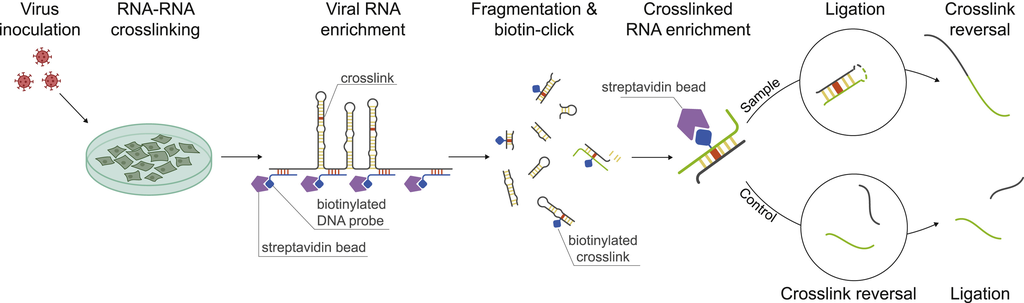

Figure from Ziv et al., 2020. Virus-inoculated cells are crosslinked using clickable psoralen. Viral RNA is pulled down from the cell lysate using an array of biotinylated DNA probes, following digestion of the DNA probes and fragmentation of the RNA. Biotin is attached to crosslinked RNA duplexes via click chemistry, enabling pulling down crosslinked RNA using streptavidin beads. Half of the RNA duplexes are proximity-ligated, following reversal of the crosslinking to enable sequencing. The other half serves as a control, in which crosslink reversal proceeds the proximity ligation

After sequencing, short reads are produced where one half of the read corresponds to one half of an RNA duplex and the other half of the reads corresponds to the other half of the RNA duplex. This package has been designed to analyse this data. The short reads need to be processed is a specific way, see the next section.

As well as the RNA of interest. In the studies above there is also structural information present for many other RNAs in the genome.

# COMRADES data pre-processing

The quickest way to get going with the analysis of your RNA interest is to download a dataset that has previously been processed and stored in GEO:

- https://www.ncbi.nlm.nih.gov/geo/query/acc.cgi?acc=GSE154662

Download the files that end in `.hyb` or `.hyb.gz` or similar. These are the the files produces by step 5 below and can be used as input to this packagae, if you do this, skip the data pre-processing section.

If you would prefer to analyse the raw data see the steps below:

1 Raw data ( .fastq ) can be downloded from:

```
https://www.ncbi.nlm.nih.gov/geo/query/acc.cgi?acc=GSE154662 or from
the other experiment mentioned above.
```

2 Cutadapt - Trimming adapters

```
parameters:    -a AGATCGGAAGAGCACACGTCTGAACTCCAGTC
               -A AGATCGGAAGAGCGTCGTGTAGGGAAAGAGTGT
               --minimum-length 10
https://cutadapt.readthedocs.io/en/stable/
```

3 Pear - Joining Paired-end reads

```
parameters:    -f R1.fastq
               -r R2.fastq
https://cme.h-its.org/exelixis/web/software/pear/
```

4 collapse.py - UMI Removal

```
parameters: --minreads 1
https://readthedocs.org/projects/umi-tools/downloads/pdf/stable/
```

5 Hyb - Finding structural duplexes

```
https://github.com/gkudla/hyb
```

## Prerequisits

- The vienna Packagae (if performing folding)
- R packages (will install automatically):
  - ggplot2
  - reshape2
  - GenomicRanges
  - igraph
  - heatmap3
  - MASS
  - mixtools
  - RColorBrewer
  - foreach
  - doParallel
  - R4RNA

## Installation

Current install is via GitHub.

```r
devtools::install_github("JLP-BioInf/comradesOO")
```

- Hyb output files

  The hyb output files
- Sample Table

  Must have 4 columns, fileName (the full path and file name of the input hyb file for each sample ), group (“s” - sample or “c” - control), sample (1,2,3, etc), sampleName (must be unique).
- RNA of interest (as annotated in the Hyb output files)

  The name of the RNA as shown the in the Hyb files.
- RNA length

# 3 classes

The package revolves around 3 connected objects. The comradesDataSet, comradesClusteredDataSet and comradesFoldedDataSet.

## comradesFoldedDataSet

# Quick Start Workflow

## Setting up

```r
## Get the sampleTable
sampleTable2 = data.frame("fileName" = paste("/path/to/sample",1:6,".hyb", sep = ""),
                          "group" = c("c","s","c","s","c","s"),
                          "sample" = c(1,1,2,2,3,3),
                          "sampleName" = paste("sample",1:6, sep = ""))


## Get the name of RNA
rna = c("ENSG00000075624_ENST00000331789_ACTB_mRNA")

rnaSize = list()
rnaSize[[rna]] = 2554
```

## Reading in data from Hyb

```r
#make comradesDataSet object
cds = comradesDataSet(rnas = rna,
                      rnaSize = rnaSize,
                      sampleTable =     sampleTable2)




# plot matrices
plotMatrices(cds = cds,
             type = "noHost",
             directory = "figures/raw",
             a = 1,
             b = rnaSize[[rna]],
             c = 1,
             d = rnaSize[[rna]],
             h = 5)
# plot matrices with replicates combined
plotMatricesAverage(cds = cds,
                    type = "noHost",
                    directory = "figures/raw",
                    a = 1,
                    b = rnaSize[[rna]],
                    c = 1,
                    d = rnaSize[[rna]],
                    h = 5)


# plot matrices
plotMatrices(cds = cds,
             type = "original",
             directory = "figures/raw",
             a = 1,
             b = rnaSize[[rna]],
             c = 1,
             d = rnaSize[[rna]],
             h = 5)

plotMatricesAverage(cds = cds,
                    type = "original",
                    directory = "figures/raw",
                    a = 1,
                    b = rnaSize[[rna]],
                    c = 1,
                    d = rnaSize[[rna]],
                    h = 5)
```

## Cluster the duplexes

```r
#make comradesDataSet object and cluster
clusteredCds = comradesClusteredDataSet(cds = cds,
                                        cores = 3)



plotMatrices(cds = clusteredCds,
             type = "originalClusters",
             directory = "figures/clustered",
             a = 1,
             b = rnaSize[[rna]],
             c = 1,
             d = rnaSize[[rna]],
             h = 5)
plotMatricesAverage(cds = clusteredCds,
                    type = "originalClusters",
                    directory = "figures/clustered",
                    a = 1,
                    b = rnaSize[[rna]],
                    c = 1,
                    d = rnaSize[[rna]],
                    h = 5)
```

## Trim clusters

```r
# trim clusters
trimmedClusters = trimClusters(clusteredCds = clusteredCds)

getClusterStats(trimmedClusters)
getDuplexStats(trimmedClusters)


plotMatrices(cds = trimmedClusters,
             type = "trimmedClusters",
             directory = "figures/trimmed",
             a = 1,
             b = rnaSize[[rna]],
             c = 1,
             d = rnaSize[[rna]],
             h = 5)

plotMatricesAverage(cds = trimmedClusters,
                    type = "trimmedClusters",
                    directory = "figures/trimmed",
                    a = 1,
                    b = rnaSize[[rna]],
                    c = 1,
                    d = rnaSize[[rna]],
                    h = 5)


plotMatricesAverage(cds = trimmedClusters,
                    type = "superClusters",
                    directory = "figures/superClusters",
                    a = 1,
                    b = rnaSize[[rna]],
                    c = 1,
                    d = rnaSize[[rna]],
                    h = 5)
```

## Compare to known structure

```r
knownMatrix = read.table("knownStructure.txt",
                      header = F)



knowClusteredCds = compareKnown(trimmedClusters,
                                knownMatrix,
                                "ENSG00000075624_ENST00000331789_ACTB_mRNA",
                                "trimmedClusters")


plotMatricesAverage(cds = knowClusteredCds,
                    type = "KnownAndNovel",
                    directory = "figures/knownAndNovel",
                    a = 1,
                    b = rnaSize[[rna]],
                    c = 1,
                    d = rnaSize[[rna]],
                    h = 5)
plotMatrices(cds = knowClusteredCds,
                    type = "KnownAndNovel",
                    directory = "figures/knownAndNovel",
                    a = 1,
                    b = rnaSize[[rna]],
                    c = 1,
                    d = rnaSize[[rna]],
                    h = 5)
plotMatricesAverage(cds = knowClusteredCds,
                    type = "novel",
                    directory = "figures/novel",
                    a = 1,
                    b = rnaSize[[rna]],
                    c = 1,
                    d = rnaSize[[rna]],
                    h = 5)
plotMatrices(cds =   knowClusteredCds,
                    type = "novel",
                    directory = "figures/novel",
                    a = 1,
                    b = rnaSize[[rna]],
                    c = 1,
                    d = rnaSize[[rna]],
                    h = 5)

plotMatrices(cds = knowClusteredCds,
                    type = "known",
                    directory = "figures/can",
                    a = 1,
                    b = rnaSize[[rna]],
                    c = 1,
                    d = rnaSize[[rna]],
                    h = 5)


plotMatricesAverage(cds = knowClusteredCds,
                    type = "known",
                    directory = "figures/can",
                    a = 1,
                    b = rnaSize[[rna]],
                    c = 1,
                    d = rnaSize[[rna]],
                    h = 5)




#get statistics of duplex level data
getDuplexStats(knowClusteredCds)

#get statistics of clusters
getClusterStats(knowClusteredCds)
```

## fold clusters

```r
# fold the trimmed clusters
foldedCds = comradesFoldedDataSet(knowClusteredCds,
                                rna = rna,
                                rnaRefs = rnaRefs)

library(seqinr)


rnaRefs = list()
rnaRefs[[rna]] = read.fasta("ACTB.fasta")
```